# Part 2: Data analysis and Decision Making

For bird observations from 2022 that fall within neighborhoods with HOLC grads, find the percent of observations within each redlining categories and plot results.

```r
bird_in_holc_grade <- st_read("data/gbif-birds-LA/gbif-birds-LA.shp") %>%
  filter(year >= 2022)
```

Prepare the Dataset for the plotting

```r
##read the shape file for the birds diveristy dataset
bird <- st_read("data/gbif-birds-LA/gbif-birds-LA.shp") %>%
        filter(year >= 2022)
##change the CRS, even without chekcing
bird_crs_transformed <- st_transform(bird_in_holc_grade, crs = st_crs(LA_redlining))

##subset only redlined areas from bird dataset
bird_subset <- bird_crs_transformed[LA_redlining, ]

## join the data with redlining using st_join, default is inner join
bird_redlined <- st_join(LA_redlining, bird_subset)

result <- bird_redlined %>% group_by(grade) %>%
          mutate(percent_of_birds = as.character(round(n()/nrow(bird_redlined)*100), 2))
```

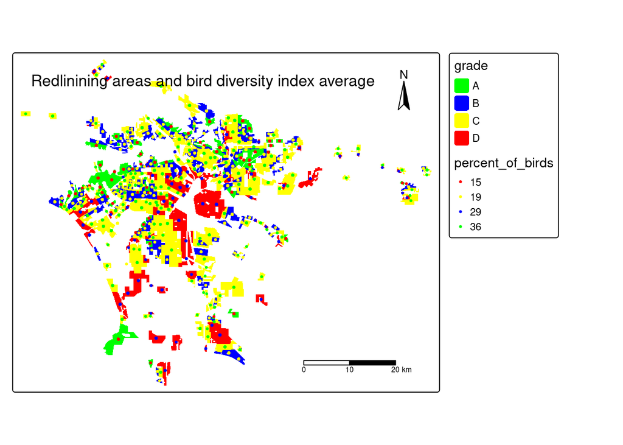

```r
########aggregate the data and plot the summarized output
tm_shape(LA_redlining)+
    tm_fill(fill = "grade", palette = c("green", "blue", "yellow", 'red'), alpha = 1)+
    tm_shape(result)+
    tm_dots(col = 'percent_of_birds', palette=c('15' ='red', '19'='yellow', '29'='blue', '36' ='green'))+
    tm_scale_bar(location = c("bottomright"), position = c("left", "bottom"))+
    tm_compass(type = "arrow", position = c("right", "top"))+
  tm_layout(title = "Redlinining areas and bird diversity index average")
```

[^1]: Gee, G. C. (2008). A multilevel analysis of the relationship between institutional and individual racial discrimination and health status. American journal of public health, 98(Supplement_1), S48-S56.
[^2]: Nardone, A., Rudolph, K. E., Morello-Frosch, R., & Casey, J. A. (2021). Redlines and greenspace: the relationship between historical redlining and 2010 greenspace across the United States. Environmental health perspectives, 129(1), 017006.
[^3]: Hoffman, J. S., Shandas, V., & Pendleton, N. (2020). The effects of historical housing policies on resident exposure to intra-urban heat: a study of 108 US urban areas. Climate, 8(1), 12.
[^4]: Ellis-Soto, D., Chapman, M., & Locke, D. H. (2023). Historical redlining is associated with increasing geographical disparities in bird biodiversity sampling in the United States. Nature Human Behaviour, 1-9.
[^5]: Robert K. Nelson, LaDale Winling, Richard Marciano, Nathan Connolly, et al., “Mapping Inequality,” American Panorama, ed. Robert K. Nelson and Edward L. Ayers, accessed October 17, 2023, https://dsl.richmond.edu/panorama/redlining/